# Descriptive statistics

# Exploration of the complete dataset

- The raw data was analysed with ionbot v0.6.2. Precursor mass tolerance and fragment mass tolerance was 20ppm. Cys Carbamidomethylation was set as a fixed PTM and Met Oxidation was set as expected (variable) PTM. Furthermore, unexpected PTMs were searched for from among all modifications in UniMod. The enzyme was set to trypsin K|R.
- No discriminating principle was used when selecting the projects to re-process.
- For each project, the detected modifications are listed, along with the class of the modification, the UNIMOD identifier, the number of PSMs for particular protein, the position of the amino acid, the amino acid where the modification was found.
  - all of the modifications are labelled using [UniMod](https://www.unimod.org/modifications_list.php?goto=6) identifiers. Furthermore, the UniProt identifier of the protein on which the modification was found is listed, the amino acid on which the modification was found and the position of the amino acid. Finally, the total counts of the PSM spectra matches are also listed.

How many projects were analysed:

```
[1] 391   1
```

## General questions

What are the most common classes of modifications?

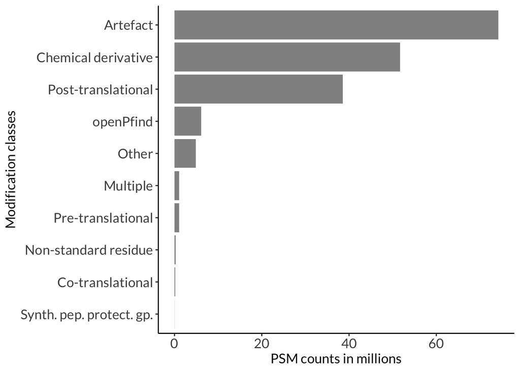

How many unique proteins are there?

```
[1] 18765     1
```

How many unique modifications?

```
[1] 1396    1
```

```
[1] 391   1
```

How many residues have been modified?

```
[1] 19  1
```

## Project sizes

The projects on PRIDE vary in sizes, number of raw files, number of samples, number of patients, patient conditions etc.

What are the IDs of projects with the most modifications?

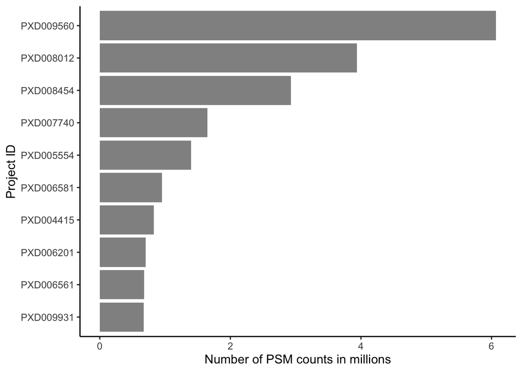

What is the distribution of the number of modifications per project and the number of raw files per project.

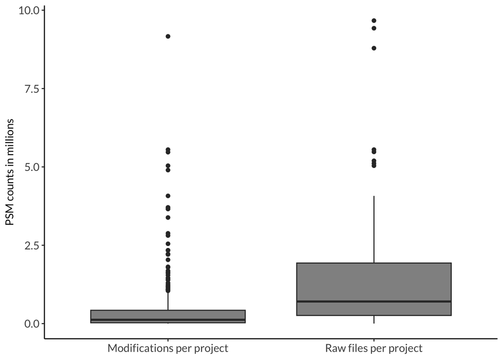

```
 [1] 9164872 5551526 5469670 5038326 4898244 4075364 3708410 3701968 3659516
[10] 3657369 3384593 2880232 2810370 2547531 2340287 2337940 2218792 2210812
[19] 2208594 2036026 1812726 1793495 1685153 9667636 9424825 8788354 5551526
[28] 5478903 5195452 5112594 5038326 4075364 3776015 3752963 3708410 3701968
[37] 3659516 3460927 3043181 3040496 2810370 2708670 2607101 2601620 2601096
[46] 2537575 2415855 2404405 2210812 2131075 2068090 2041675 2036026 1828588
[55] 1685153 1677890
```

```
[1] 56
```

What is the distribution of abundances?

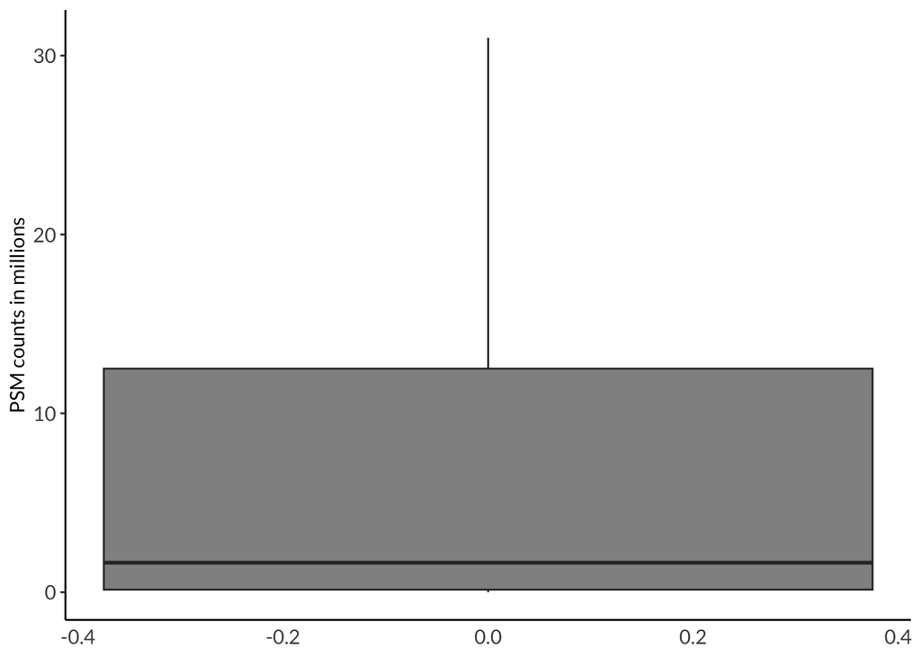

```r
d <- human_complete %>%
  dplyr::select(Uniprot_entry_name, abundance) %>%
  distinct()

ggplot(d,aes(y = abundance)) +
  geom_boxplot(outliers = F, fill = '#919191') +
  labs(y = 'PSM counts in millions') +
  theme_classic() +
  theme(legend.title = element_blank(),
        axis.title.x = element_blank(),
        axis.ticks.x = element_blank(),
        legend.text = element_text(size = 11, family = "Lato"),
        axis.text = element_text(size = 11, family = "Lato"),
        axis.title = element_text(size = 11, family = "Lato"))
```

How many outliers are there?

```r
outliers <- boxplot.stats(d$abundance)$out
print(outliers) # these the the PTM counts that were excluded
```

[output not shown]

[output cut: 278 more lines]

```r
length(outliers)
```

```
[1] 2630
```

# Post-translational

## General questions

How many unique proteins are there?

```
[1] 16665     1
```

How many unique modifications?

```
[1] 138   1
```

```
[1] 389   1
```

How many residues have been modified?

```
[1] 19  1
```

What are the most common PTMs?

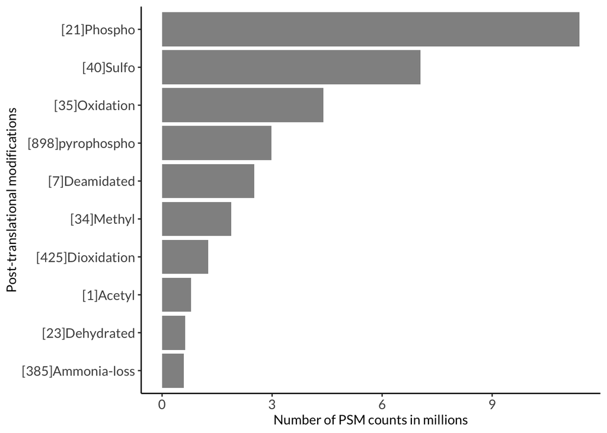

## Amino acid level

When looking at the dataset on the amino acid level, all of the amino acids have some type of modifications apart from leucine (L).

It is also interesting to look at whether some amino acids get modified more than others. Serine is by far the most modified amino acid.

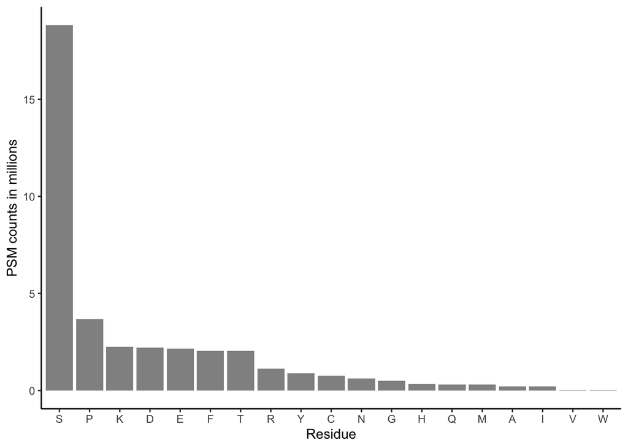

However, when looking at the number of different PTMs per residue, we can see that lysine and cysteine are susceptible to a larger variety of PTMs compared to serine.

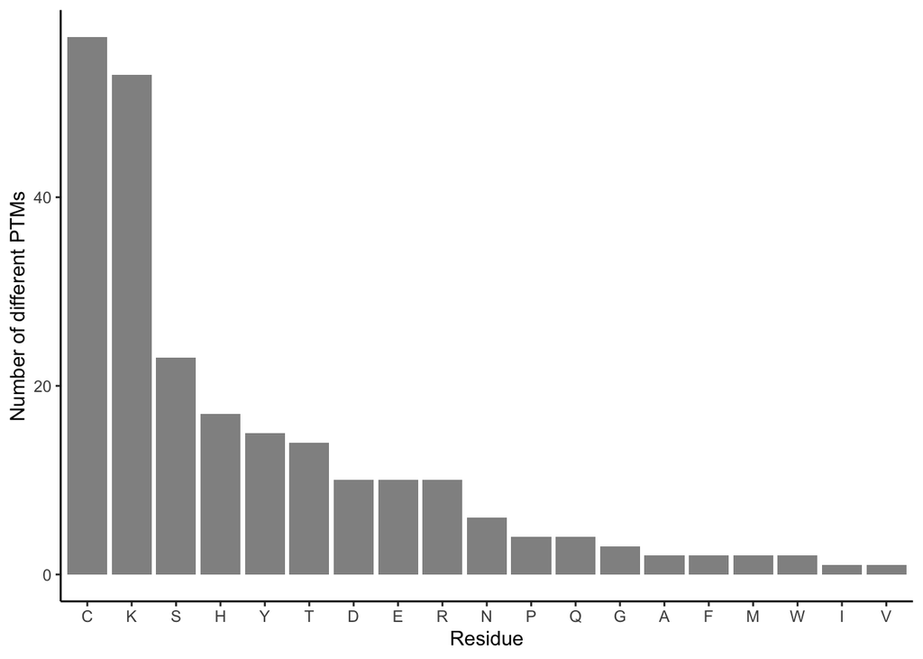

Create a table with all of the modifications per amino acid:

Summary of PTMs by Residue

| ptm_res | PTMs |
| --- | --- |
| A | [53]HNE; [37]Trimethyl |
| C | [1]Acetyl; [21]Phospho; [40]Sulfo; [440]Amidino; [382]Cys->PyruvicAcid; [407]Hydroxycinnamyl; [421]Sulfide; [53]HNE; [55]Glutathione; [1388]HN2_mustard; [438]Cyano; [402]Cys->Oxoalanine; [387]Phycocya… |
| D | [34]Methyl; [35]Oxidation; [21]Phospho; [299]Carboxy; [421]Sulfide; [447]Deoxy; [39]Methylthio; [434]CHDH; [1356]phosphoRibosyl; [424]MolybdopterinGD |
| E | [299]Carboxy; [34]Methyl; [450]Glu; [452]GluGluGlu; [21]Phospho; [451]GluGlu; [1356]phosphoRibosyl; [396]GlycerylPE; [453]GluGluGluGlu; [436]Hydroxyheme |
| F | [7]Deamidated; [340]Bromo |
| G | [420]Carboxy->Thiocarboxy; [822]Gly-loss+Amide; [45]Myristoyl |
| H | [34]Methyl; [50]FAD; [21]Phospho; [1389]HN3_mustard; [375]Diphthamide; [53]HNE; [2027]His+O(2); [1388]HN2_mustard; [1017]DMPO; [409]FMNH; [390]Heme; [340]Bromo; [417]PhosphoUridine; [405]Phosphoadenos… |
| I | [34]Methyl |
| K | [1848]Gluratylation; [1849]hydroxyisobutyryl; [747]Malonyl; [1042]Acetyldeoxyhypusine; [1043]Acetylhypusine; [1289]Butyryl; [422]PyruvicAcidIminyl; [299]Carboxy; [64]Succinyl; [352]Lys->Allysine; [946… |
| M | [299]Carboxy; [425]Dioxidation |
| N | [23]Dehydrated; [36]Dimethyl; [34]Methyl; [35]Oxidation; [414]Hydroxymethyl; [39]Methylthio |
| P | [35]Oxidation; [425]Dioxidation; [529]Delta:H(5)C(2); [36]Dimethyl |
| Q | [23]Dehydrated; [34]Methyl; [528]Methyl+Deamidated; [1992]serotonylation |
| R | [35]Oxidation; [1913]glyoxalAGE; [36]Dimethyl; [7]Deamidated; [425]Dioxidation; [21]Phospho; [1356]phosphoRibosyl; [505]LG-lactam-R; [34]Methyl; [506]LG-Hlactam-R |
| S | [34]Methyl; [403]Ser->LacticAcid; [1419]15N-oxobutanoic; [23]Dehydrated; [1]Acetyl; [385]Ammonia-loss; [1355]azole; [442]FMN; [21]Phospho; [40]Sulfo; [401]Didehydro; [431]Palmitoleyl; [449]Decanoyl; [… |
| T | [1]Acetyl; [23]Dehydrated; [1419]15N-oxobutanoic; [385]Ammonia-loss; [34]Methyl; [21]Phospho; [40]Sulfo; [426]Octanoyl; [405]Phosphoadenosine; [1843]PhosphoCytidine; [898]pyrophospho; [449]Decanoyl; [… |
| V | [422]PyruvicAcidIminyl |
| W | [392]Quinone; [340]Bromo |
| Y | [35]Oxidation; [401]Didehydro; [400]Tyr->Dha; [392]Quinone; [425]Dioxidation; [23]Dehydrated; [21]Phospho; [40]Sulfo; [1017]DMPO; [405]Phosphoadenosine; [1843]PhosphoCytidine; [50]FAD; [417]PhosphoUri… |

## Protein level

In total there are 16665 unique proteins in the dataset.

When looking at the most commonly modified proteins, we can see that the top 10 most modified proteins include albumin (ALBU_HUMAN), collagen (CO1A1_HUMAN, CO1A2_HUMAN, CO3A1_HUMAN), actin (ACTB_HUMAN) etc. Only post-translational modifications were taken into account.

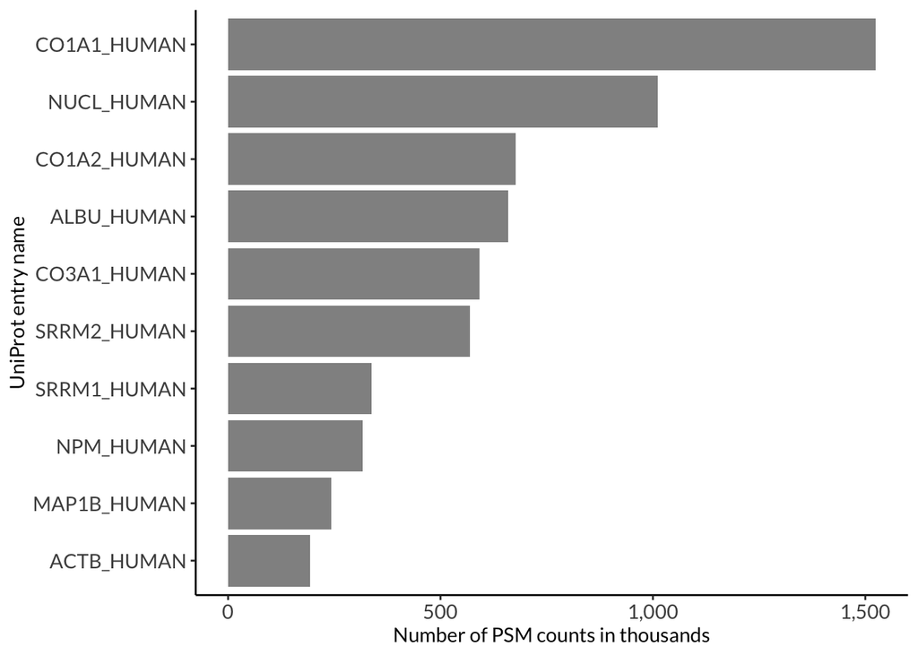

Throughout this notebook, only raw counts were used. However this does not take into account the varying sample sizes within each project, the increased chances of a protein being modified if it is longer or has a high level of expression in cells. Therefore, normalisation is required.